# Spatially Variable Genes

Recall in the BANKSY lesson we noted that the BANKSY algorithm identified different, spatially constrained subtypes in this cancerous region. For example, we can zoom in clusters 13, 14, and 15.

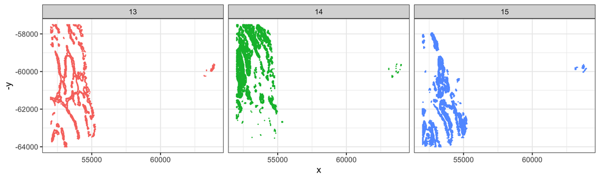

```r
# Grab x and y coordinates for plotting
# Also get the sample ID and the banksy cluster score for each bin
df <- FetchData(crc_sub,
                vars = c("x", "y",
                         "banksy_cluster"))

# Subset to one sample (P5CRC)
ggplot(df %>% subset(banksy_cluster %in% c(13, 14, 15)),
       # Plot spatial coordinates and color by cluster
       aes(x = x, y = -y,
           color = banksy_cluster)) +
  geom_point(size = 0.05) +
  theme_bw() +
  # Create separate plots for each cluster
  facet_wrap(~banksy_cluster) +
  NoLegend()
```

Interestingly, clusters 14 and 15 appear to be associated with the top and bottom of the tissue. This suggests that there is a spatial organization of cells with different function.

So now we can begin to see which of those genes were defining the phenotype of these tumor subtypes.

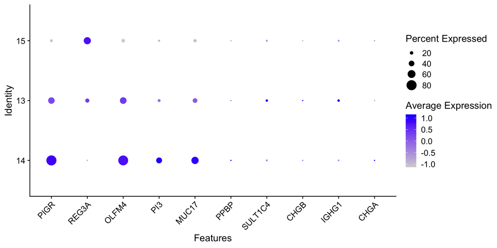

Figure 4: DotPlot of BANKSY cancerous clusters, showing top tumor spatially variable genes.

```r
# Dotplot of tumor clusters for top SVGs
DotPlot(crc_sub,
        top10_svg,
        group.by = "banksy_cluster",
        cluster.idents = TRUE,
        idents = c(13, 14, 15)) +
  theme(axis.text.x = element_text(angle = 45, hjust = 1))
```

A distinct phenotype emerges for each group of cancerous regions.

For instance, cluster 14 shows strong expression of [OLFM4](https://www.nature.com/articles/s42003-023-05504-8), a known marker of intestinal stem cells and tumor cells typically located at the base of epithelial crypts. These cells differentiate into secretory lineages, resembling Paneth cells, which are not usually present in the colon. Furthermore, this differentiation is associated with reduced cell adhesion capabilities.

In contrast, cluster 15 is characterized by high expression of REG3A, which plays a key role in modulating gut microbiome interactions by killing Gram-positive bacteria. Increased REG3A expression has been reported in multiple cancer types and is typically associated with enhanced proliferation of [endocrine cells](https://www.nature.com/articles/s42003-023-04616-5).

We can see that while both clusters 14 and 15 are tumor cells, they differ both spatially and in gene expression. Meanwhile, cluster 13 appears to be a transient state between the two populations. Using spatially variable genes, we can start defining regions of the tissue and annotate the function of those regions. This will help us understand the spatial organization of the tissue.

**Exercise 1**

1. Pick a different cell type and run `FindSpatiallyVariableFeatures()`. Name the population you chose and print the top 6 genes in the results.

## SVG use cases and methods

There are many different use cases of these SVGs, for example:

- Instead of HVGs as input for PCA, use SVGs to run the workflow all the way to clustering
- Identify spatial regions based upon top SVGs (e.g cortical layers)
- Classify subtypes of broader cell types

As the field of spatial transcriptomics is ever evolving, there are other algorithms that utilize different priors to identify spatially variable genes. Some methods include, but are not limited to:

- [SpatialDE](https://www.nature.com/articles/nmeth.4636)
- [MERINGUE](https://genome.cshlp.org/content/31/10/1843.long)
- [BinSpect](https://link.springer.com/article/10.1186/s13059-021-02286-2)

Note that some of these are written in Python.

Next Lesson >>

Back to Schedule